# Direct benevolence manipulation analysis by context

Matt Jaquiery (matt.jaquiery@psy.ox.ac.uk)

July 2019

[Script run 2019-11-25 13:27:15]

# Introduction

Observations from [evolutionary models](https://github.com/oxacclab/EvoEgoBias) show that egocentric discounting is a successful strategy in environments where advisors sometimes provide deliberately poor advice. We reason that human participants may show a sensitivity to these contextual factors underlying advice-taking and respond to them in a rational manner. To test the effects of potentially misleading advice, we used a direct benevolence manipulation in a judge-advisor system. Participants had two experimental blocks: in one they were told the advisors would consistently try to help them (“‘honest’ advisors”), and in the other they were told the advisors may occasionally try to mislead them (“‘deceptive’ advisors”). In reality, all advisors offered advice drawn from the same distribution, which was centred on the correct answer (i.e. all of the advice was helpful on avereage).

We hypothesised that participants would place greater weight on the advice of the ‘honest’ vs ‘deceptive’ advisors, and that this relationship would be mediated by responses to questionnaires asking about the perceived benevolence of the advisors.

The study was [pre-registered](https://osf.io/qjey5). Differences from the pre-registered script:

- Minor fixes after collecting 4 participants’ data:
  - Fixed phantom levels in categorical variables
  - Fixed percentage calculation for participants showing ‘honest’ > ‘deceptive’ pattern for weight on advice

# Method

The experimental code is available on [GitHub](https://github.com/oxacclab/ExploringSocialMetacognition), and the experiement can be performed by visiting [https://acclab.psy.ox.ac.uk/~mj221/ESM/ACv2/dbc.html](https://acclab.psy.ox.ac.uk/~mj221/ESM/ACv2/dbc.html?PROLIFIC_PID=WriteUp).

# Results

## Exclusions

```
                               HonestFirst DeceptiveFirst
  attnCheckYear outlyingTrials           5              5
  badQQLabels                            4              4
  FALSE                                 21             24
  outlyingTrials                         2              0
  pChange                                0              1
```

Our final participant list consists of 45 participants who completed an average of 11.93 trials each.

## Task performance

First we offer a characterisation of the task, to provide the reader with a sense of how the participants performed.

### Decisions

Participants offered estimates of the year in which various events took place. The correct answers were always between 1900 and 2000, although the timeline on which participants responded went from 1890 to 2010 in order to allow extra room for advice. Participants answered by dragging a marker onto a timeline which covered a range of 11 years (e.g. 1940-1950). Participants were informed that a correct answer was one in which the marker covered the year in which the event took place.

#### Correctness

Responses are regarded as **correct** if the target year is included within the marker range.

| decision | mean\|m=11 |
| --- | --- |
| first | .350 |
| last | .445 |

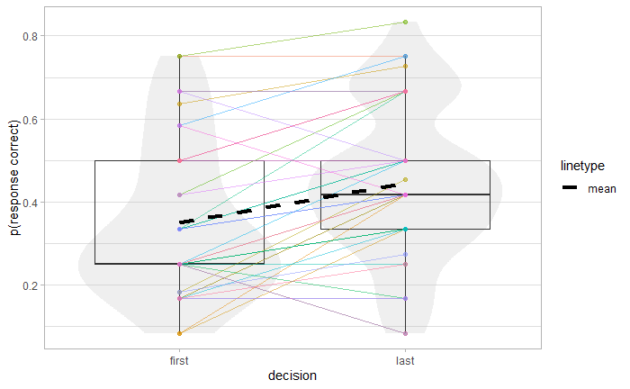

#### Error (estimate mean)

The **error** is calcualted as the distance from the centre of the answer marker to the correct year. It is thus possible for **correct** answers to have non-zero error, and it is likely that the error for correct answers scales with the marker size.

| decision | mean\|m=11 |
| --- | --- |
| first | 18.432 |
| last | 15.143 |

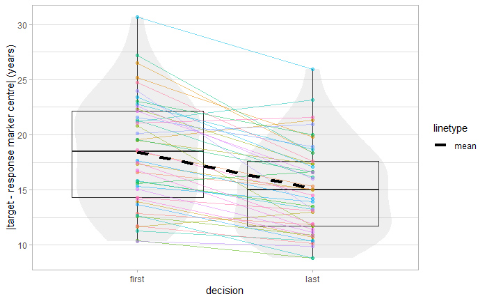

### Timing

We can look at the response time - the difference between the time the response is opened and the time the response is received.

| decision | mean\|m=11 |
| --- | --- |
| first | 9462.372 |
| last | 20194.783 |

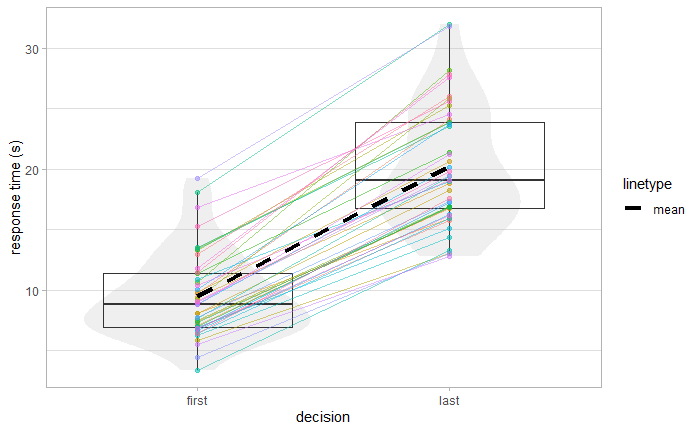

### Summary

For the most part, participants’ final answers were closer to the correct answer, and more likely to include the correct answer, as compared to their intial answers. This suggests that they took the advice into account.

*N.B.: participants who do not adjust their answers following advice on >90% of trials are excluded.*

## Advisor performance

The advice offered should be equivalent between in/out group advisors.

### Accuracy

| advisor | accuracy | error |
| --- | --- | --- |
| deceptive | .396 | 8.687 |
| honest | .355 | 9.134 |

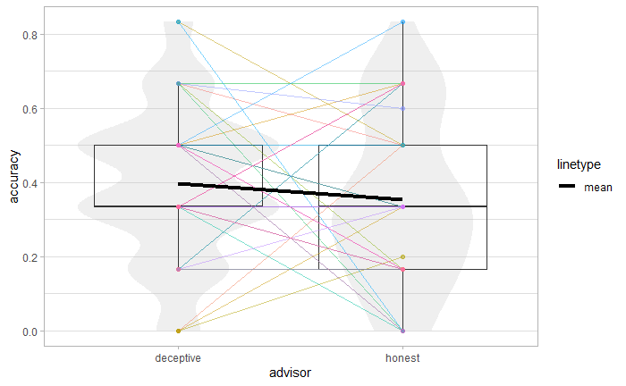

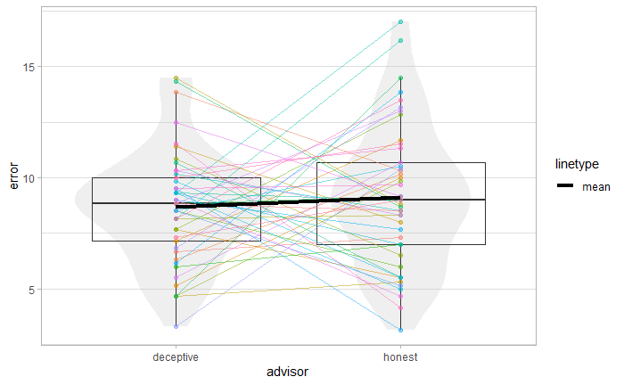

### Agreement

| advisor | agreement |
| --- | --- |
| deceptive | .190 |
| honest | .227 |

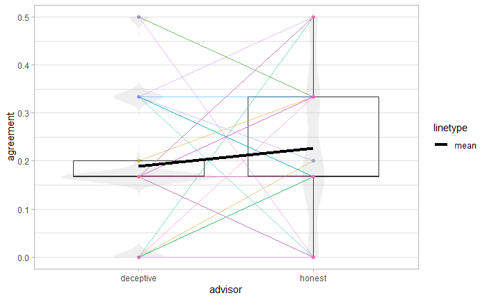

### Distance

Distance is the continuous version of agreement - the difference between the centre of the advice and the centre of the initial estimate.

| advisor | distance |
| --- | --- |
| deceptive | 18.692 |
| honest | 17.684 |

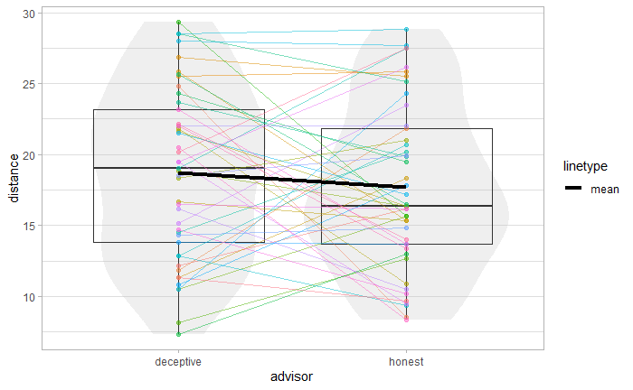

### Summary

The advice offered by the advisors was designed to be equivalent, and was similar in practice. The ‘deceptive’ advisors were slightly more accurate and had slightly lower average error, although the difference is unlikely to be meaningful. The same is true for agreement and advice distance, although these metrics showed more desirable scores for the ‘honest’ advisors.

### Influence

The measure of influence is weight-on-advice. This is well-defined for values between 0 and 1 (trucated otherwise), and is
$$\text{WoA} = (\text{final} - \text{inital}) / (\text{advice} - \text{initial})$$
, or the degree to which the final decision moves towards the advised answer.

Influence is the primary outcome measure, and is thus expected to differ between advisors and feedback conditions.

| advisor | WoA |
| --- | --- |
| deceptive | .300 |
| honest | .490 |

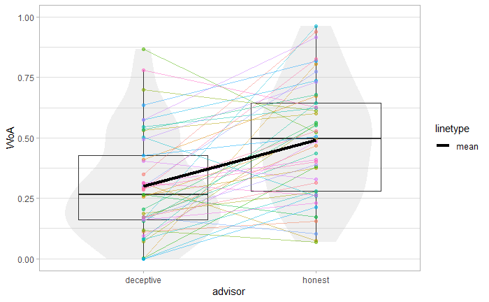

##### WoA distribution

It’s good to keep a general eye on the distribution of weight-on-advice on a trial-by-trial basis.

```
Ignoring unknown parameters: binwidth, bins, pad
```

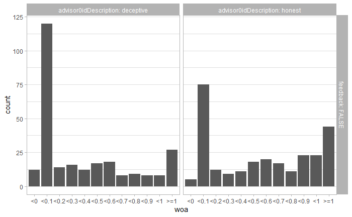

### Summary

#### WoA by Advice

We also want to know if weight on advice differs as a function of how participants rate the advice itself.

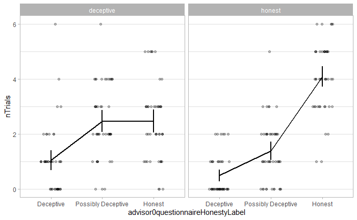

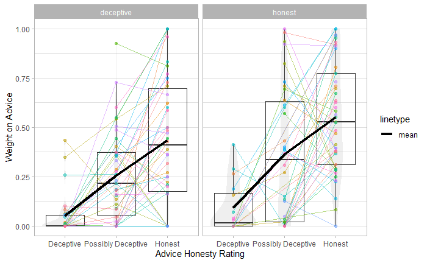

#### Summary

As shown by the number of trials labelled a particular way for each advisor group, advice was more likely to be rated as “Honest” if it came from the ‘honest’ advisors. Both advisor groups show an increase in how influential the advice was as a function of how the advice was rated, and the influence of advice may be slightly higher for the ‘honest’ advisors at each label level.

## Hypothesis testing

The hypotheses being tested here are:

1. Participants will place higher weight on the advice of ‘honest’ advisors, which we will test for advice rated as honest.
2. Participants will place greater weight on advice on honest- vs deceptive-rated advice.

### 1. Group differences

Participants have different weight-on-advice for ‘honest’ as opposed to ‘deceptive’ advisors.

*t*(41) = 2.67, *p* = .011, *d* = 0.41, BF = 3.74; *M*|honest = 0.55 [0.47, 0.64], *M*|deceptive = 0.43 [0.33, 0.53]

### Summary

Where advice was labelled as “Honest” by the participants, advice was more influential when coming from ‘honest’ advisors. Participants are thus less willing to trust advice from a potentially dubious source even when that advice is perceived as being genuine. This effect is moderately sized.

### 2. Effect of advice rating

Participants should place greater weight on advice they rate as honest vs deceptive.

*t*(33) = -8.98, *p* < .001, *d* = 2.11, BF = 47014041.03; *M*|deceptive = 0.06 [0.03, 0.10], *M*|honest = 0.52 [0.42, 0.62]

### Summary

Participants are less influenced by advice they perceive as being misleading. This effect is enormous.

## Exploration

### Advisor differences for other advice types

Honest (unpaired): *t*(81) = 1.81, *p* = .074, *d* = 0.39, BF = 0.95; *M*|honest = 0.55 [0.47, 0.64], *M*|deceptive = 0.43 [0.33, 0.53] Honest (paired): *t*(41) = 2.67, *p* = .011, *d* = 0.41, BF = 3.74; *M*|honest = 0.55 [0.47, 0.64], *M*|deceptive = 0.43 [0.33, 0.53]

Possibly Deceptive (unpaired): *t*(54.82) = 1.57, *p* = .123, *d* = 0.38, BF = 0.75; *M*|honest = 0.36 [0.24, 0.48], *M*|deceptive = 0.26 [0.18, 0.33] Possibly Deceptive (paired): *t*(31) = 1.72, *p* = .095, *d* = 0.36, BF = 0.71; *M*|honest = 0.36 [0.23, 0.49], *M*|deceptive = 0.25 [0.17, 0.34]

Deceptive (unpaired): *t*(26.45) = 1.03, *p* = .313, *d* = 0.34, BF = 0.49; *M*|honest = 0.09 [0.02, 0.16], *M*|deceptive = 0.05 [0.01, 0.09] Deceptive (paired): *t*(10) = 0.02, *p* = .986, *d* = 0.01, BF = 0.30; *M*|honest = 0.07 [0.00, 0.15], *M*|deceptive = 0.07 [-0.02, 0.17]

### Unpaired advice contrasts by rating

(unpaired) *t*(84.62) = 4.19, *p* < .001, *d* = 0.89, BF = 307.56; *M*|Honest = 0.51 [0.43, 0.59], *M*|Possibly Deceptive = 0.30 [0.23, 0.36] (paired) *t*(43) = -4.69, *p* < .001, *d* = 0.86, BF = 778.27; *M*|Honest = 0.30 [0.23, 0.36], *M*|Possibly Deceptive = 0.50 [0.42, 0.58]

(unpaired) *t*(59.48) = 10.41, *p* < .001, *d* = 2.13, BF = 200500764622.97; *M*|Honest = 0.51 [0.43, 0.59], *M*|Deceptive = 0.06 [0.03, 0.10] (paired) *t*(33) = -8.98, *p* < .001, *d* = 2.11, BF = 47014041.03; *M*|Honest = 0.06 [0.03, 0.10], *M*|Deceptive = 0.52 [0.42, 0.62]

(unpaired) *t*(63.55) = 6.27, *p* < .001, *d* = 1.32, BF = 69468.24; *M*|Possibly Deceptive = 0.30 [0.23, 0.36], *M*|Deceptive = 0.06 [0.03, 0.10] (paired) *t*(32) = -5.10, *p* < .001, *d* = 1.30, BF = 1444.70; *M*|Possibly Deceptive = 0.06 [0.03, 0.10], *M*|Deceptive = 0.28 [0.21, 0.36]

### Mean distance of advice by rating and advisor

If participants are more vigilant when receiving advice from the ‘deceptive’ advisor, they may classify the advice as deceptive more readily.

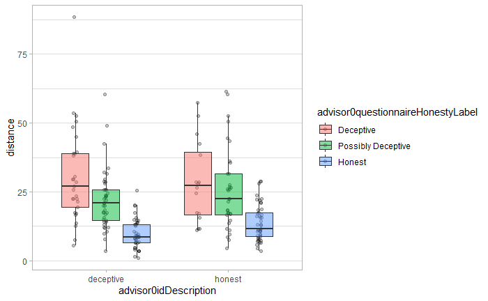

#### Summary

There does not seem to be a clear difference in the criteria used to judge the deceptiveness of advice as a function of the labels of the advisors.

### WoA where advice is taken

For parity with previous versions we can look at weight on advice for trials where advice is taken: does it still differ between the advisors?

| advisor0idDescription | p.adviceIgnored_m | p.adviceIgnored_sd |
| --- | --- | --- |
| deceptive | 0.4600000 | 0.2990389 |
| honest | 0.2822222 | 0.2428368 |

```
*t*(40) = 2.97, *p*  = .005, *d* = 0.60, BF = 7.39; honest = 0.68 [0.62, 0.74], deceptive = 0.56 [0.49, 0.63]
```

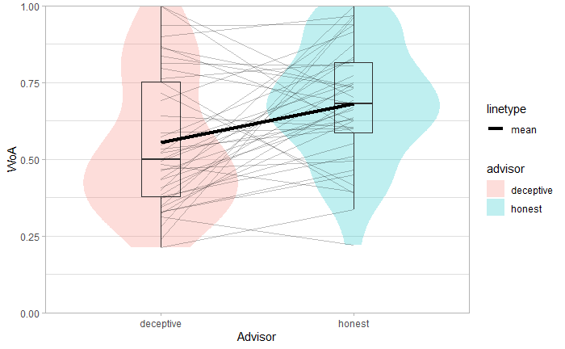

# Conclusions

Both the properties of the source of advice and the advice itself are important for determining the influence of a piece of advice. That said, the properties of the advice are far more important than the properties of the advisor - people will mostly take advice on its own merit.

The properties of the advice may have been far more influential because the properties of the advisor influenced the rating of the advice: if it were harder for advice from ‘deceptive’ advisors to be rated as “Honest” then much of the explanatory power of the advisor would be hidden by the explanatory power of the advice. The exploratory analysis of advice rating distance by advisor indicated that this was not the case, however: participants were more likely to rate advice as “Deceptive” from ‘deceptive’ advisors, but not more so as a consequence of the distance between their initial estimate and the advice estimate (a measure of advice plausibility).

It seems, then, that labelling some advisors as potentially ‘deceptive’ made participants more likely to perceive their advice as “Deceptive”. This is a blanket adjustment, and not an interaction with advice distance. Once the advice is labelled by the participant, the labelling of the advisor does make a slight difference in the influence of advice, but this is dwarfed by the difference made by the participant’s own labelling of the advice.

# Credits

## Acknowledgements

Thanks as always to Nick Yeung and the other folks at the [ACC Lab](https://www.psy.ox.ac.uk/research/attention-cognitive-control-lab).

## R Packages

| Package | Citations |
| --- | --- |
| base | R Core Team (2018). R: A language and environment for statistical computing. R Foundation for Statistical Computing, Vienna, Austria. URL https://www.R-project.org/. |
| beepr | Rasmus Bååth (2018). beepr: Easily Play Notification Sounds on any Platform. R package version 1.3. https://CRAN.R-project.org/package=beepr |
| curl | Jeroen Ooms (2019). curl: A Modern and Flexible Web Client for R. R package version 4.0. https://CRAN.R-project.org/package=curl |
| knitr | Yihui Xie (2019). knitr: A General-Purpose Package for Dynamic Report Generation in R. R package version 1.24. Yihui Xie (2015) Dynamic Documents with R and knitr. 2nd edition. Chapman and Hall/CRC. I… |
| ez | Michael A. Lawrence (2016). ez: Easy Analysis and Visualization of Factorial Experiments. R package version 4.4-0. https://CRAN.R-project.org/package=ez |
| prettyMD | Matt Jaquiery (2018). prettyMD: Format Test Outputs with Markdown. R package version 0.1.0. |
| BayesMed | Michele B. Nuijten, Ruud Wetzels, Dora Matzke, Conor V. Dolan and Eric-Jan Wagenmakers (2015). BayesMed: Default Bayesian Hypothesis Tests for Correlation, Partial |
| Correlation, and Mediation. R package version 1.0.1. https://CRAN.R-project.org/package=BayesMed |  |
| MCMCpack | Andrew D. Martin, Kevin M. Quinn, Jong Hee Park (2011). MCMCpack: Markov Chain Monte Carlo in R. Journal of Statistical Software. 42(9): 1-21. URL http://www.jstatsoft.org/v42/i09/. |
| MASS | Venables, W. N. & Ripley, B. D. (2002) Modern Applied Statistics with S. Fourth Edition. Springer, New York. ISBN 0-387-95457-0 |
| polspline | Charles Kooperberg (2019). polspline: Polynomial Spline Routines. R package version 1.1.15. https://CRAN.R-project.org/package=polspline |
| QRM | Bernhard Pfaff and Alexander McNeil (2016). QRM: Provides R-Language Code to Examine Quantitative Risk Management |
| Concepts. R package version 0.4-13. https://CRAN.R-project.org/package=QRM |  |
| timeSeries | Diethelm Wuertz, Tobias Setz and Yohan Chalabi (2017). timeSeries: Rmetrics - Financial Time Series Objects. R package version 3042.102. https://CRAN.R-project.org/package=timeSeries |
| timeDate | Diethelm Wuertz, Tobias Setz, Yohan Chalabi, Martin Maechler and Joe W. Byers (2018). timeDate: Rmetrics - Chronological and Calendar Objects. R package version 3043.102. https://CRAN.R-project.org/pa… |
| numDeriv | Paul Gilbert and Ravi Varadhan (2019). numDeriv: Accurate Numerical Derivatives. R package version 2016.8-1.1. https://CRAN.R-project.org/package=numDeriv |
| mvtnorm | Alan Genz, Frank Bretz, Tetsuhisa Miwa, Xuefei Mi, Friedrich Leisch, Fabian Scheipl, Torsten Hothorn (2019). mvtnorm: Multivariate Normal and t Distributions. R package version 1.0-11. URL http://CRAN… |
| gsl | R. K. S. Hankin 2006. Special functions in R: introducing the gsl package. R News 6(4) |
| R2jags | Yu-Sung Su and Masanao Yajima, (2015). R2jags: Using R to Run ‘JAGS’. R package version 0.5-7. https://CRAN.R-project.org/package=R2jags |
| rjags | Martyn Plummer (2019). rjags: Bayesian Graphical Models using MCMC. R package version 4-9. https://CRAN.R-project.org/package=rjags |
| BayesFactor | Richard D. Morey and Jeffrey N. Rouder (2018). BayesFactor: Computation of Bayes Factors for Common Designs. R package version 0.9.12-4.2. https://CRAN.R-project.org/package=BayesFactor |
| Matrix | Douglas Bates and Martin Maechler (2019). Matrix: Sparse and Dense Matrix Classes and Methods. R package version 1.2-17. https://CRAN.R-project.org/package=Matrix |
| coda | Martyn Plummer, Nicky Best, Kate Cowles and Karen Vines (2006). CODA: Convergence Diagnosis and Output Analysis for MCMC, R News, vol 6, 7-11 |
| broom | David Robinson and Alex Hayes (2019). broom: Convert Statistical Analysis Objects into Tidy Tibbles. R package version 0.5.2. https://CRAN.R-project.org/package=broom |
| forcats | Hadley Wickham (2019). forcats: Tools for Working with Categorical Variables (Factors). R package version 0.4.0. https://CRAN.R-project.org/package=forcats |
| stringr | Hadley Wickham (2019). stringr: Simple, Consistent Wrappers for Common String Operations. R package version 1.4.0. https://CRAN.R-project.org/package=stringr |
| dplyr | Hadley Wickham, Romain François, Lionel Henry and Kirill Müller (2019). dplyr: A Grammar of Data Manipulation. R package version 0.8.3. https://CRAN.R-project.org/package=dplyr |
| purrr | Lionel Henry and Hadley Wickham (2019). purrr: Functional Programming Tools. R package version 0.3.2. https://CRAN.R-project.org/package=purrr |
| readr | Hadley Wickham, Jim Hester and Romain Francois (2018). readr: Read Rectangular Text Data. R package version 1.3.1. https://CRAN.R-project.org/package=readr |
| tidyr | Hadley Wickham and Lionel Henry (2019). tidyr: Easily Tidy Data with ‘spread()’ and ‘gather()’ Functions. R package version 0.8.3. https://CRAN.R-project.org/package=tidyr |
| tibble | Kirill Müller and Hadley Wickham (2019). tibble: Simple Data Frames. R package version 2.1.3. https://CRAN.R-project.org/package=tibble |
| ggplot2 | H. Wickham. ggplot2: Elegant Graphics for Data Analysis. Springer-Verlag New York, 2016. |
| tidyverse | Hadley Wickham (2017). tidyverse: Easily Install and Load the ‘Tidyverse’. R package version 1.2.1. https://CRAN.R-project.org/package=tidyverse |
| testthat | Hadley Wickham. testthat: Get Started with Testing. The R Journal, vol. 3, no. 1, pp. 5–10, 2011 |

## Funding

Matt Jaquiery is funded by a studentship from the [Medical Research Council](https://mrc.ukri.org/) (reference 1943590) and the University of Oxford [Department of Experimental Psychology](https://www.psy.ox.ac.uk/) (reference 17/18_MSD_661552).